# *Boosting Claims Predictions: an Analysis on Kaggle Data*

## `target` vs. features

### `target` vs. interval features

The `10` `interval` features can be plotted against the `target` variable in either jitter plots or boxplots for the purpose of visual exploration of their distributions. Below we show a simple code chunk for producing jitter plots for the variables `ps_reg_03`, `ps_car_12` is provided; however, for sake of clarity in the exposition boxplots will be preferred.

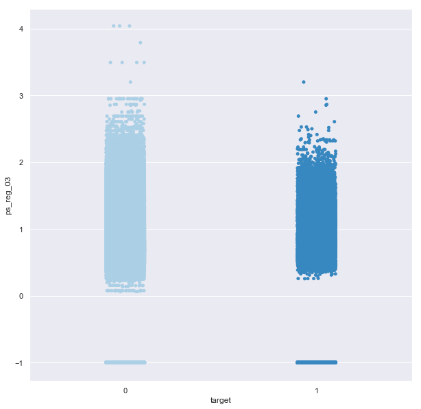

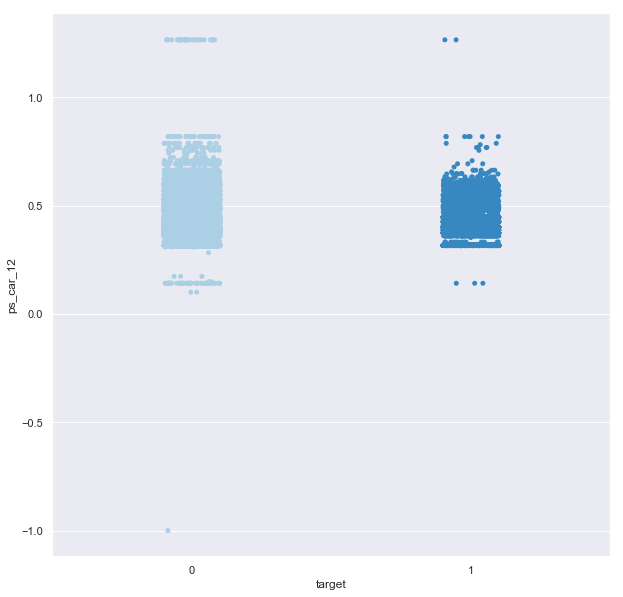

```python
# jitter plots: an example
sns.set( rc = {'figure.figsize': (10, 10)})
feat = list(['ps_reg_03', 'ps_car_12'])

for f in feat:
    plt.figure()
    sns.stripplot(y=f, x='target', data=data, jitter=True, palette="Blues")
    plt.show()
```

Additional diagrams are given below. One starts with `ps_reg_01`:

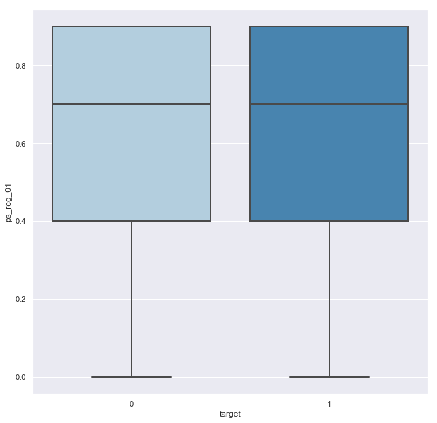

```python
# ps_reg_01
sns.set( rc = {'figure.figsize': (10, 10)})
sns.boxplot(x='target', y='ps_reg_01', data=data, linewidth=2, palette="Blues")
```

No relevant discrimination of the variable distributions along the `target` levels is detected. Then `ps_reg_02`:

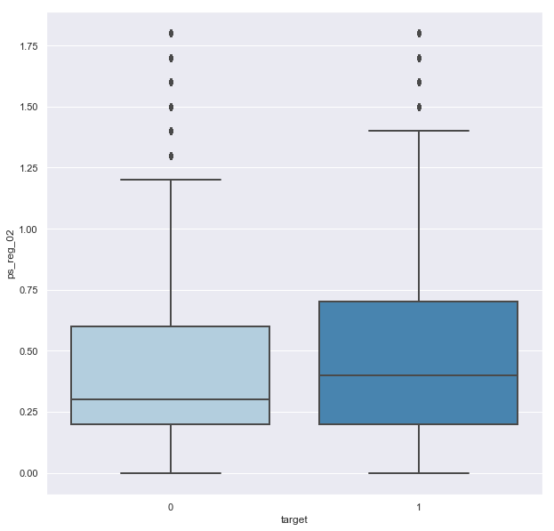

```python
# ps_reg_02
sns.set( rc = {'figure.figsize': (10, 10)})
sns.boxplot(x= "target", y ="ps_reg_02", data=data, linewidth=2, palette="Blues")
```

The variable distribution along the `target=1` level shows a wider spread w.r.t. the distribution along `target=0`. Few outliers are detected. One continues with `ps_reg_03`:

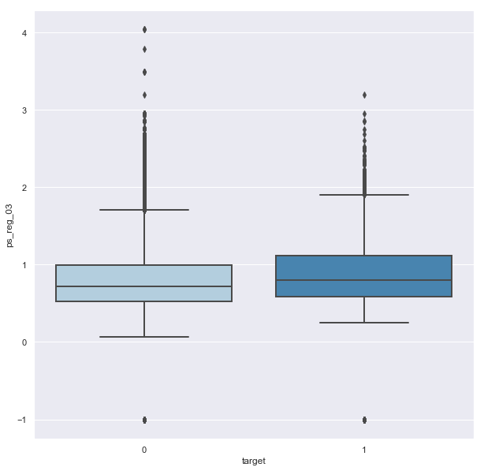

```python
# ps_reg_03
sns.set( rc = {'figure.figsize': (10, 10)})
sns.boxplot(x='target', y ='ps_reg_03', data=data, linewidth=2, palette="Blues")
```

Relevant presence of outliers is identified; missing values are present for records with both `0` and `1` values of the `target` variable. On the other hand `ps_car_12`:

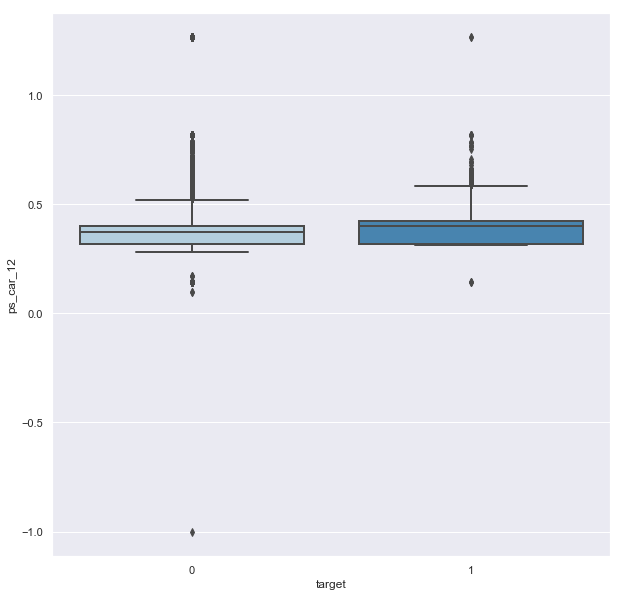

```python
# ps_car_12
sns.set( rc = {'figure.figsize': (10, 10)})
sns.boxplot(x='target', y='ps_car_12', data=data, linewidth=2, palette="Blues")
```

Missing values are not present for records with `target=1`. Moving to `ps_car_13`:

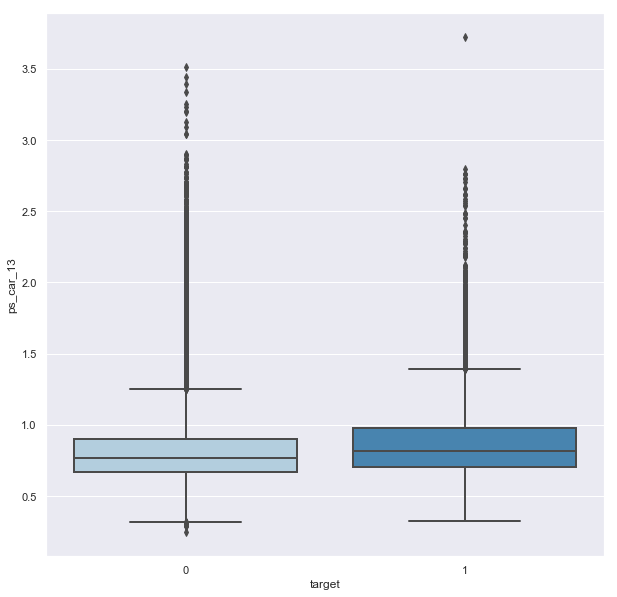

```python
# ps_car_13
sns.set( rc = {'figure.figsize': (10, 10)})
sns.boxplot(x='target', y='ps_car_13', data=data, linewidth=2, palette="Blues")
```

Strong presence of outliers, especially along `target=0`. Then `ps_car_14`:

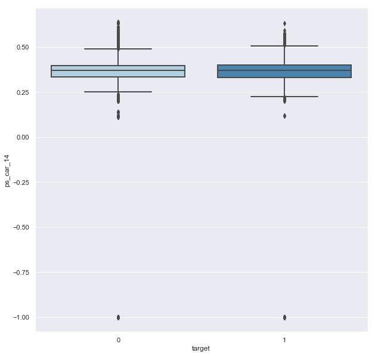

```python
# ps_car_14
sns.set( rc = {'figure.figsize': (10, 10)})
sns.boxplot(x='target', y='ps_car_14', data=data, linewidth=2, palette="Blues")
```

Outliers and missing values for both `target` levels are detected. Then `ps_car_15`:

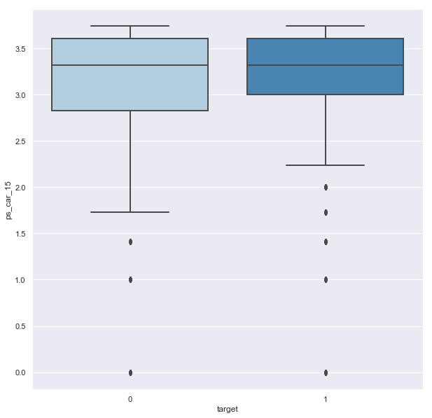

```python
# ps_car_15
sns.set( rc = {'figure.figsize': (10, 10)})
sns.boxplot(x='target', y='ps_car_15', data=data, linewidth=2, palette="Blues")
```

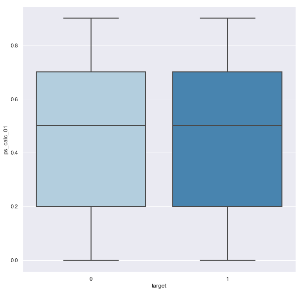

```python
# ps_calc_01
sns.set( rc = {'figure.figsize': (10, 10)})
sns.boxplot(x='target', y='ps_calc_01', data=data, linewidth=2, palette="Blues")
```

Continuing with `ps_calc_02`

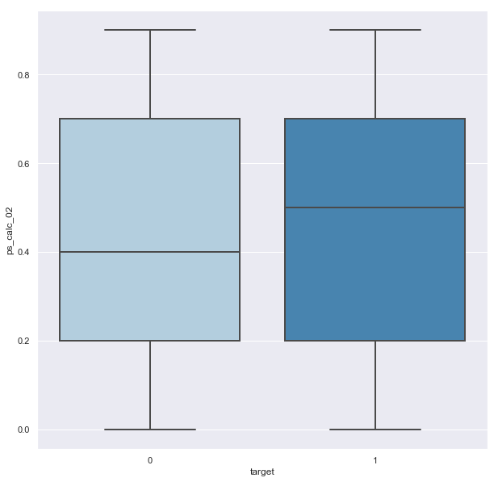

```python
# ps_calc_02
sns.set( rc = {'figure.figsize': (10, 10)})
sns.boxplot(x='target', y='ps_calc_02', data=data, linewidth=2, palette="Blues")
```

and finishing with `ps_calc_03`

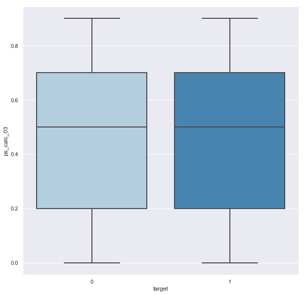

```python
# ps_calc_03
sns.set( rc = {'figure.figsize': (10, 10)})
sns.boxplot(x='target', y='ps_calc_03', data=data,linewidth=2, palette="Blues")
```

### `target` vs. binary, categorical and ordinal features

One moves to the visual analysis of plots of `target` against the remaining variables in `data` and cross-tabulations for `binary` data.

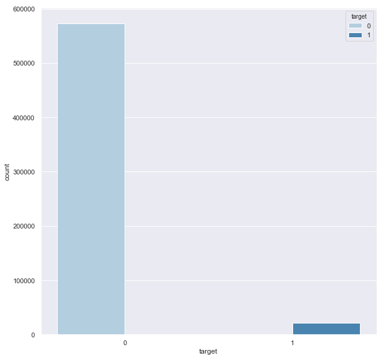

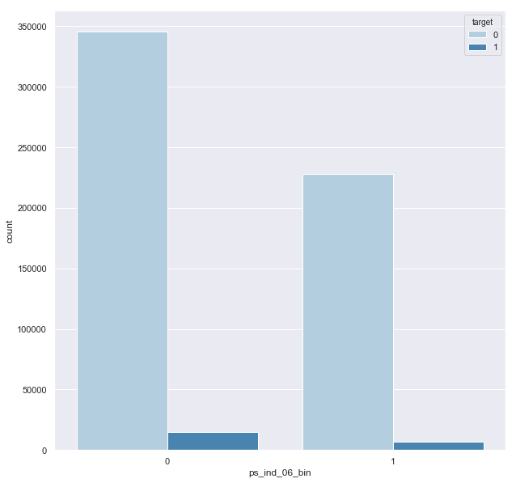

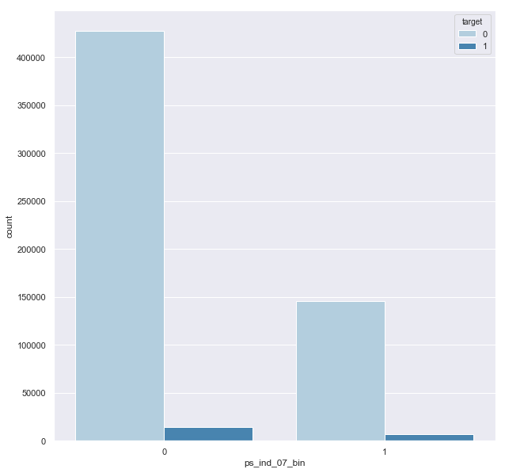

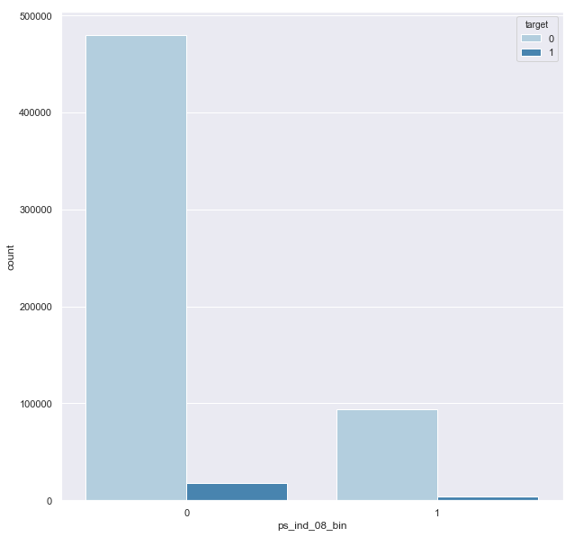

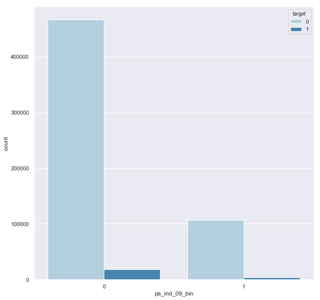

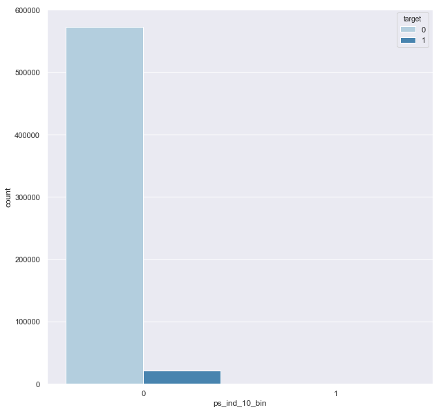

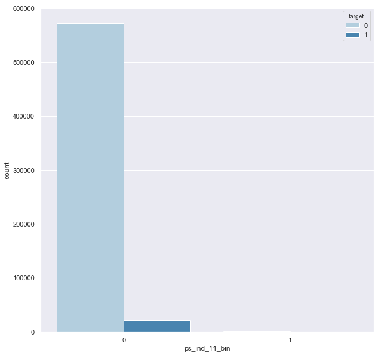

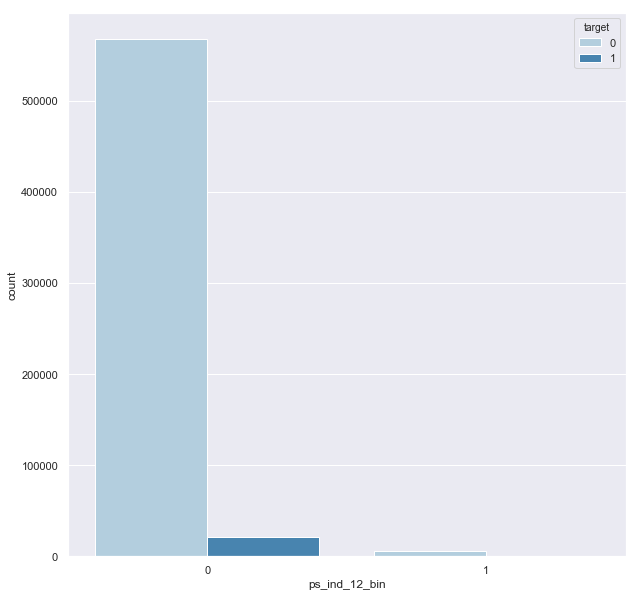

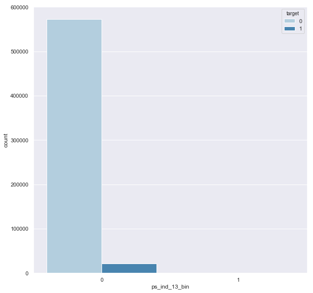

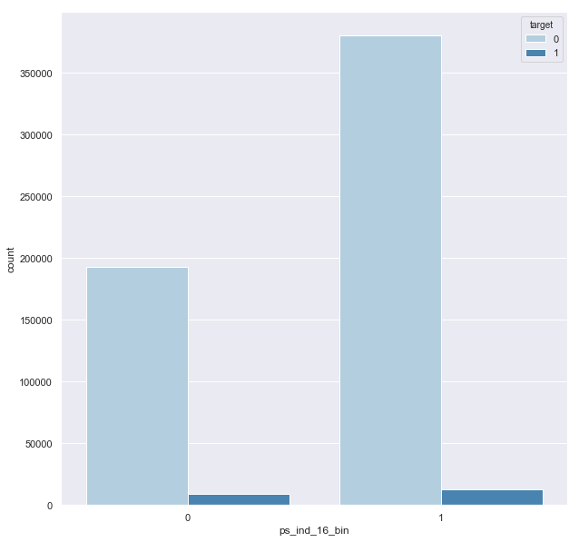

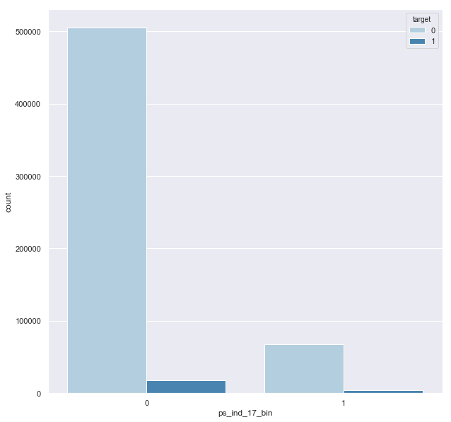

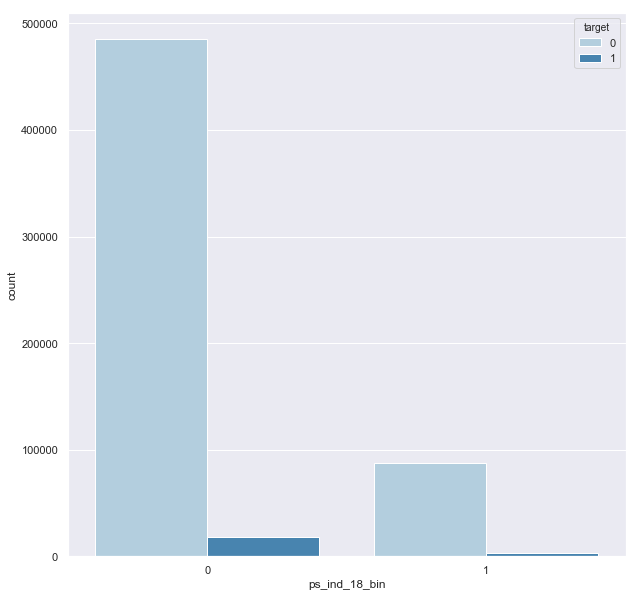

[6 more figures not shown]

```python
# binary features
sns.set( rc = {'figure.figsize': (10, 10)})
feat = meta[(meta.level == 'binary') & (meta.keep)].index

for f in feat:
    plt.figure()
    sns.countplot(x=data[f], hue=data.target, data=data, palette="Blues")
    plt.show()
```

```python
# for binary make a cross-tabulation rows : levels columns: 0/1 in %; sum of every row = 100%
v = meta[(meta.level == 'binary') & (meta.keep)].index.drop('target')

for f in v:
    crosstab = pd.crosstab(index=data[f], columns=data['target'], margins=True)
    cross = pd.DataFrame(data=crosstab.div(crosstab['All'], axis=0).drop('All', 1))
    cross['All'] = crosstab.iloc[:,2]
    print(cross)
    print()
    print()
```

```
target                0         1     All
ps_ind_06_bin
0              0.958415  0.041585  360852
1              0.971463  0.028537  234360
All            0.963552  0.036448  595212


target                0         1     All
ps_ind_07_bin
0              0.967324  0.032676  442223
1              0.952650  0.047350  152989
All            0.963552  0.036448  595212


target                0         1     All
ps_ind_08_bin
0              0.964643  0.035357  497644
1              0.957988  0.042012   97568
All            0.963552  0.036448  595212


target                0         1     All
ps_ind_09_bin
0              0.962816  0.037184  484917
1              0.966789  0.033211  110295
All            0.963552  0.036448  595212


target                0         1     All
ps_ind_10_bin
0              0.963559  0.036441  594990
1              0.945946  0.054054     222
All            0.963552  0.036448  595212


target                0         1     All
ps_ind_11_bin
0              0.963568  0.036432  594205
1              0.954320  0.045680    1007
All            0.963552  0.036448  595212
```

[output cut: 62 more lines]

```
All             0.963552  0.036448  595212


target                 0         1     All
ps_calc_19_bin
0               0.963313  0.036687  387469
1               0.963999  0.036001  207743
All             0.963552  0.036448  595212


target                 0         1     All
ps_calc_20_bin
0               0.963467  0.036533  503955
1               0.964025  0.035975   91257
All             0.963552  0.036448  595212
```

A quick visual check suggests that no binary variable presents `0` or `1` levels showing a significant deviation from the global 96.4-3.6 noise-signal ratio. Moreover, no zero frequency cell is identified; zero cells can lead to numerical instability during the training routines (e.g. for logistic regression models). One continues with cross-tabulation of `target` against ordinal variables.

```python
 # for ordinal make a cross-tabulation rows : levels columns: 0/1 in %; sum of every row = 100%
v = meta[(meta.level == 'ordinal') & (meta.keep)].index

for f in v:
    crosstab = pd.crosstab(index=data[f], columns=data['target'], margins=True)
    cross = pd.DataFrame(data=crosstab.div(crosstab['All'], axis=0).drop('All', 1))
    cross['All'] = crosstab.iloc[:,2]
    print(cross)
    print()
    print()
```

```
target            0         1     All
ps_ind_01
0          0.966779  0.033221  187594
1          0.966371  0.033629  143984
2          0.963137  0.036863   82468
3          0.959037  0.040963   51193
4          0.954868  0.045132   33524
5          0.959684  0.040316   61464
6          0.956849  0.043151   17682
7          0.957869  0.042131   17303
All        0.963552  0.036448  595212


target            0         1     All
ps_ind_03
```

[output cut: 255 more lines]

`calc` variables are characterized by zero cells for a limited number of variable levels. For example, zero cells appear for `ps_calc_12` at levels `ps_calc_12 == 9` and `ps_calc_12 == 10`. The number of records associated to levels for which complete separation holds, i.e. the emergence of zero cells in the cross-tabulation against `target`, is extremely low for all `calc` variables. In absence of additional information on provided data, it is not possible to produce inference on those data points, which could represent outliers to remove before modeling or records for which the absence of `target == 1` is fully justified by business considerations.

# Feature Engineering & Data Preparation for Modeling

In this section we perform a series of transformations on `data` to pave the way to predictive modeling.

## On numerical `calc` variables and univariate screening

As mentioned in the document, the numerical `calc` variables will be dropped from further analysis, starting with a quick structural check on `data` and ending with a drop check.

```python
print('Structure of data before calc variable drop:', data.shape)
```

```
Structure of data before calc variable drop: (595212, 59)
```

```python
# dropping 'ps_calc_01',... 'ps_calc_14' variables and updating meta information
vars_to_drop = ['ps_calc_01', 'ps_calc_02','ps_calc_03','ps_calc_04','ps_calc_05','ps_calc_06','ps_calc_07','ps_calc_08','ps_calc_09','ps_calc_10','ps_calc_11','ps_calc_12','ps_calc_13','ps_calc_14']
data.drop(vars_to_drop, inplace = True, axis = 1)
meta.loc[(vars_to_drop), 'keep'] = False
```

```python
print('Structure of data after calc variable drop:', data.shape)
```

```
Structure of data after calc variable drop: (595212, 45)
```

```python
data.info()
```

```
<class 'pandas.core.frame.DataFrame'>
RangeIndex: 595212 entries, 0 to 595211
Data columns (total 45 columns):
id                595212 non-null int64
target            595212 non-null int64
ps_ind_01         595212 non-null int64
ps_ind_02_cat     595212 non-null int64
ps_ind_03         595212 non-null int64
ps_ind_04_cat     595212 non-null int64
ps_ind_05_cat     595212 non-null int64
ps_ind_06_bin     595212 non-null int64
ps_ind_07_bin     595212 non-null int64
ps_ind_08_bin     595212 non-null int64
ps_ind_09_bin     595212 non-null int64
ps_ind_10_bin     595212 non-null int64
ps_ind_11_bin     595212 non-null int64
ps_ind_12_bin     595212 non-null int64
ps_ind_13_bin     595212 non-null int64
ps_ind_14         595212 non-null int64
ps_ind_15         595212 non-null int64
ps_ind_16_bin     595212 non-null int64
ps_ind_17_bin     595212 non-null int64
ps_ind_18_bin     595212 non-null int64
ps_reg_01         595212 non-null float64
ps_reg_02         595212 non-null float64
ps_reg_03         595212 non-null float64
ps_car_01_cat     595212 non-null int64
ps_car_02_cat     595212 non-null int64
ps_car_03_cat     595212 non-null int64
ps_car_04_cat     595212 non-null int64
ps_car_05_cat     595212 non-null int64
ps_car_06_cat     595212 non-null int64
ps_car_07_cat     595212 non-null int64
ps_car_08_cat     595212 non-null int64
ps_car_09_cat     595212 non-null int64
ps_car_10_cat     595212 non-null int64
ps_car_11_cat     595212 non-null int64
ps_car_11         595212 non-null int64
ps_car_12         595212 non-null float64
ps_car_13         595212 non-null float64
ps_car_14         595212 non-null float64
ps_car_15         595212 non-null float64
ps_calc_15_bin    595212 non-null int64
ps_calc_16_bin    595212 non-null int64
ps_calc_17_bin    595212 non-null int64
ps_calc_18_bin    595212 non-null int64
ps_calc_19_bin    595212 non-null int64
ps_calc_20_bin    595212 non-null int64
dtypes: float64(7), int64(38)
memory usage: 204.3 MB
```

## Imputation of missing values

As discussed in the document, a straighforward imputation scheme is chosen and applied in the forthcoming code chunk:

```python
# dropping 'ps_car_03_cat', 'ps_car_05_cat' and updating meta information
vars_to_drop = ['ps_car_03_cat', 'ps_car_05_cat']
data.drop(vars_to_drop, inplace = True, axis = 1)
meta.loc[(vars_to_drop), 'keep'] = False

# imputing with the mean or mode using Imputer from sklearn.preprocessing
from sklearn.preprocessing import Imputer

mean_imp = Imputer(missing_values = -1, strategy = 'mean', axis = 0)
mode_imp = Imputer(missing_values = -1, strategy = 'most_frequent', axis = 0)

data['ps_reg_03'] = mean_imp.fit_transform(data[['ps_reg_03']]).ravel()
data['ps_car_12'] = mean_imp.fit_transform(data[['ps_car_12']]).ravel()
data['ps_car_14'] = mean_imp.fit_transform(data[['ps_car_14']]).ravel()
data['ps_car_11'] = mode_imp.fit_transform(data[['ps_car_11']]).ravel()
```

After imputation one has

```python
print(data.shape)
```

```
(595212, 43)
```

## Dummies

Dummy variables for categorical features in `data` are created; the function `get_dummies` converts categorical variables into dummies dropping the original categorical variable from which the corresponding dummies are created from the resulting dataset and the first level. One-hot-encoding does not drop the first level, instead.

```python
# selecting categorical variables
v = meta[(meta.level == 'categorical') & (meta.keep)].index
print('Before dummification we have {} variables in train'.format(data.shape[1]))

# creating dummy variables
data = pd.get_dummies(data, columns = v, drop_first = True)
print('After dummification we have {} variables in data'.format(data.shape[1]))
```

```
Before dummification we have 43 variables in train
After dummification we have 197 variables in data
```

After generation of dummy variables, the memory usage of the `data` dataset is increased:

```python
print('Memory usage of `data` (in bytes):', pd.DataFrame.memory_usage(data,index=True, deep = True).sum())
```

```
Memory usage of `data` (in bytes): 246417848
```

One can check that no categorical variable is present in the resulting dataset, as expected:

```python
v = meta[(meta.level == 'categorical') & (meta.keep)].index
data[v]
```

[output not shown]

A quick check on the columns of `data` after dummification ends this section:

```python
print(data.columns.values)
```

```
['id' 'target' 'ps_ind_01' 'ps_ind_03' 'ps_ind_06_bin' 'ps_ind_07_bin'
 'ps_ind_08_bin' 'ps_ind_09_bin' 'ps_ind_10_bin' 'ps_ind_11_bin'
 'ps_ind_12_bin' 'ps_ind_13_bin' 'ps_ind_14' 'ps_ind_15' 'ps_ind_16_bin'
 'ps_ind_17_bin' 'ps_ind_18_bin' 'ps_reg_01' 'ps_reg_02' 'ps_reg_03'
 'ps_car_11' 'ps_car_12' 'ps_car_13' 'ps_car_14' 'ps_car_15'
 'ps_calc_15_bin' 'ps_calc_16_bin' 'ps_calc_17_bin' 'ps_calc_18_bin'
 'ps_calc_19_bin' 'ps_calc_20_bin' 'ps_ind_02_cat_1' 'ps_ind_02_cat_2'
 'ps_ind_02_cat_3' 'ps_ind_02_cat_4' 'ps_ind_04_cat_0' 'ps_ind_04_cat_1'
 'ps_ind_05_cat_0' 'ps_ind_05_cat_1' 'ps_ind_05_cat_2' 'ps_ind_05_cat_3'
 'ps_ind_05_cat_4' 'ps_ind_05_cat_5' 'ps_ind_05_cat_6' 'ps_car_01_cat_0'
 'ps_car_01_cat_1' 'ps_car_01_cat_2' 'ps_car_01_cat_3' 'ps_car_01_cat_4'
 'ps_car_01_cat_5' 'ps_car_01_cat_6' 'ps_car_01_cat_7' 'ps_car_01_cat_8'
 'ps_car_01_cat_9' 'ps_car_01_cat_10' 'ps_car_01_cat_11' 'ps_car_02_cat_0'
 'ps_car_02_cat_1' 'ps_car_04_cat_1' 'ps_car_04_cat_2' 'ps_car_04_cat_3'
 'ps_car_04_cat_4' 'ps_car_04_cat_5' 'ps_car_04_cat_6' 'ps_car_04_cat_7'
 'ps_car_04_cat_8' 'ps_car_04_cat_9' 'ps_car_06_cat_1' 'ps_car_06_cat_2'
 'ps_car_06_cat_3' 'ps_car_06_cat_4' 'ps_car_06_cat_5' 'ps_car_06_cat_6'
 'ps_car_06_cat_7' 'ps_car_06_cat_8' 'ps_car_06_cat_9' 'ps_car_06_cat_10'
 'ps_car_06_cat_11' 'ps_car_06_cat_12' 'ps_car_06_cat_13'
 'ps_car_06_cat_14' 'ps_car_06_cat_15' 'ps_car_06_cat_16'
 'ps_car_06_cat_17' 'ps_car_07_cat_0' 'ps_car_07_cat_1' 'ps_car_08_cat_1'
 'ps_car_09_cat_0' 'ps_car_09_cat_1' 'ps_car_09_cat_2' 'ps_car_09_cat_3'
 'ps_car_09_cat_4' 'ps_car_10_cat_1' 'ps_car_10_cat_2' 'ps_car_11_cat_2'
 'ps_car_11_cat_3' 'ps_car_11_cat_4' 'ps_car_11_cat_5' 'ps_car_11_cat_6'
 'ps_car_11_cat_7' 'ps_car_11_cat_8' 'ps_car_11_cat_9' 'ps_car_11_cat_10'
 'ps_car_11_cat_11' 'ps_car_11_cat_12' 'ps_car_11_cat_13'
 'ps_car_11_cat_14' 'ps_car_11_cat_15' 'ps_car_11_cat_16'
 'ps_car_11_cat_17' 'ps_car_11_cat_18' 'ps_car_11_cat_19'
 'ps_car_11_cat_20' 'ps_car_11_cat_21' 'ps_car_11_cat_22'
 'ps_car_11_cat_23' 'ps_car_11_cat_24' 'ps_car_11_cat_25'
 'ps_car_11_cat_26' 'ps_car_11_cat_27' 'ps_car_11_cat_28'
 'ps_car_11_cat_29' 'ps_car_11_cat_30' 'ps_car_11_cat_31'
 'ps_car_11_cat_32' 'ps_car_11_cat_33' 'ps_car_11_cat_34'
 'ps_car_11_cat_35' 'ps_car_11_cat_36' 'ps_car_11_cat_37'
 'ps_car_11_cat_38' 'ps_car_11_cat_39' 'ps_car_11_cat_40'
 'ps_car_11_cat_41' 'ps_car_11_cat_42' 'ps_car_11_cat_43'
 'ps_car_11_cat_44' 'ps_car_11_cat_45' 'ps_car_11_cat_46'
 'ps_car_11_cat_47' 'ps_car_11_cat_48' 'ps_car_11_cat_49'
 'ps_car_11_cat_50' 'ps_car_11_cat_51' 'ps_car_11_cat_52'
 'ps_car_11_cat_53' 'ps_car_11_cat_54' 'ps_car_11_cat_55'
 'ps_car_11_cat_56' 'ps_car_11_cat_57' 'ps_car_11_cat_58'
 'ps_car_11_cat_59' 'ps_car_11_cat_60' 'ps_car_11_cat_61'
 'ps_car_11_cat_62' 'ps_car_11_cat_63' 'ps_car_11_cat_64'
 'ps_car_11_cat_65' 'ps_car_11_cat_66' 'ps_car_11_cat_67'
 'ps_car_11_cat_68' 'ps_car_11_cat_69' 'ps_car_11_cat_70'
 'ps_car_11_cat_71' 'ps_car_11_cat_72' 'ps_car_11_cat_73'
 'ps_car_11_cat_74' 'ps_car_11_cat_75' 'ps_car_11_cat_76'
 'ps_car_11_cat_77' 'ps_car_11_cat_78' 'ps_car_11_cat_79'
 'ps_car_11_cat_80' 'ps_car_11_cat_81' 'ps_car_11_cat_82'
 'ps_car_11_cat_83' 'ps_car_11_cat_84' 'ps_car_11_cat_85'
 'ps_car_11_cat_86' 'ps_car_11_cat_87' 'ps_car_11_cat_88'
 'ps_car_11_cat_89' 'ps_car_11_cat_90' 'ps_car_11_cat_91'
 'ps_car_11_cat_92' 'ps_car_11_cat_93' 'ps_car_11_cat_94'
 'ps_car_11_cat_95' 'ps_car_11_cat_96' 'ps_car_11_cat_97'
 'ps_car_11_cat_98' 'ps_car_11_cat_99' 'ps_car_11_cat_100'
 'ps_car_11_cat_101' 'ps_car_11_cat_102' 'ps_car_11_cat_103'
 'ps_car_11_cat_104']
```

## On Randomness

We now fix a `random_state` for reproducibility of results; it will be used in both train vs. test dataset splitting and modeling.

```python
random_state = 123
```

## `train` and `test` datasets

As mentioned in the document, `data` dataset is randomly split into `train` and `test` datasets. A not stratified approach is chosen and removal of both columns `id` and `target` from the training dataset is performed.

```python
# split 80-20% (no stratification)
X_train, X_test, y_train, y_test = train_test_split(data.drop(['id', 'target'], axis=1),
                                                    data['target'],
                                                    test_size=0.2,
                                                    random_state=random_state
                                                   )
```

After the split, the following checks on the `train` and `test` datasets are performed:

```python
# structural checks
print('Training dataset - dimensions:', X_train.shape)
print('Test dataset - dimensions:', X_test.shape)
print()
print('Random split check:', X_train.shape[0] + X_test.shape[0] == data.shape[0])
print()

# imbalancing: check
lev_target = ( pd.crosstab(index = data['target'], columns = 'count') / data.shape[0] ) * 100
lev_target_train = ( pd.crosstab(index = y_train, columns = 'count') / y_train.shape[0] ) * 100
lev_target_test = ( pd.crosstab(index = y_test, columns = 'count') / y_test.shape[0] ) * 100

print('target class imbalance data:')
print(lev_target)
print()
print('target class imbalance train:')
print(lev_target_train)
print()
print('target class imbalance test:')
print(lev_target_test)
```

```
Training dataset - dimensions: (476169, 195)
Test dataset - dimensions: (119043, 195)

Random split check: True

target class imbalance data:
col_0       count
target
0       96.355248
1        3.644752

target class imbalance train:
col_0       count
target
0       96.380277
1        3.619723

target class imbalance test:
col_0       count
target
0       96.255135
1        3.744865
```

We then remove the original dataset `data` to free up some memory.

```python
del data
```

We can export both `X_train` and `X_test` for later use, if needed:

```python
# insert paths to export training and test data sets
X_train.to_csv('D:\\学习资料 RUC 硕\\硕一上\\现代统计精算模型\\boosting\\X_train.csv')
X_test.to_csv('D:\\学习资料 RUC 硕\\硕一上\\现代统计精算模型\\boosting\\X_test.csv')
```

# Modeling

## Modeling Strategies: short description

For the overview of the forthcoming modeling strategies we refer to the document.

## On the Porto Seguro challenge performance metric: normalized Gini coefficient

The evaluation of fitted model on out-of-sample data is performed in the Porto Seguro Kaggle challenge by considering an ad-hoc performance measure, called normalized Gini coefficient, as discussed [here](https://www.kaggle.com/c/porto-seguro-safe-driver-prediction#evaluation). The code for the computation of the normalized Gini coefficient is provided in this [thread](https://www.kaggle.com/c/ClaimPredictionChallenge/discussion/703), for different programming languages. Below the Python implementation is presented.

```python
from sklearn.metrics import make_scorer

# Gini coefficient
def gini(actual, pred):

    # a structural check
    assert (len(actual) == len(pred))

    # introducing an array called all
    all = np.asarray(np.c_[actual, pred, np.arange(len(actual))], dtype=np.float)  #slicing along second axis

    # sorting the array along predicted probabilities (descending order) and along the index axis all[:, 2] in case of ties
    all = all[np.lexsort((all[:, 2], -1 * all[:, 1]))]                             #

    # towards the Gini coefficient
    totalLosses = all[:, 0].sum()
    giniSum = all[:, 0].cumsum().sum() / totalLosses

    giniSum -= (len(actual) + 1) / 2.
    return giniSum / len(actual)

# normalized Gini coefficient
def gini_normalized_score(actual, pred):
    return gini(actual, pred) / gini(actual, actual)

# score using the normalized Gini
score_gini = make_scorer(gini_normalized_score, greater_is_better=True, needs_threshold = True)
```

## Boosting: AdaBoost

We start the boosting analysis with **AdaBoost**. We do implement 3 separate strategies: **ST0**, **ST1** and **ST2**.

#### ST0: default AdaBoost with `AdaBoostClassifier()`

Default AdaBoost with `AdaBoostClassifier()` is used for baseline modeling; we compare both SAMME and SAMME.R algorithms.

```python
# weak learner: tree stump
tree = DecisionTreeClassifier(criterion='gini',                 #only Gini and information gain criteria are supported
                              random_state= random_state,       #DecisionTreeClassifier() is not fully deterministic
                              max_depth=1)                      #stump
tree = tree.fit(X_train, y_train)

# SAMME AdaBoost
ada = AdaBoostClassifier(base_estimator=tree,
                         algorithm='SAMME',
                         random_state= random_state)
ada = ada.fit(X_train, y_train)

# SAMME.R AdaBoost
ada_R = AdaBoostClassifier(base_estimator=tree,
                           algorithm='SAMME.R',
                           random_state= random_state)
ada_R = ada_R.fit(X_train, y_train)
```

The default AdaBoost implementation uses `n_estimators=50` and `learning_rate=1.0`. Out-of-sample performance for both SAMME and SAMME.R is computed below:

```python
# SAMME AdaBoost classifier performance
y_pred_proba_ada = ada.predict_proba(X_test)
fpr, tpr, _ = roc_curve(y_test, y_pred_proba_ada[:, 1])
roc_auc = auc(fpr, tpr)

# SAMME.R AdaBoost classifier performance
y_pred_proba_ada_R = ada_R.predict_proba(X_test)
fpr_R, tpr_R, _ = roc_curve(y_test, y_pred_proba_ada_R[:, 1])
roc_auc_R = auc(fpr_R, tpr_R)

# AUC on test dataset
print('AUC SAMME AdaBoost:', roc_auc_score(y_test, y_pred_proba_ada[:, 1]).round(3))
print('AUC SAMME.R AdaBoost:', roc_auc_score(y_test, y_pred_proba_ada_R[:, 1]).round(3))
```

```
AUC SAMME AdaBoost: 0.612
AUC SAMME.R AdaBoost: 0.635
```

#### ST1 or *interlude*: explorative comparison between SAMME and SAMME.R

```python
# number of boosting iterations
n_estimators = 500

# tree stump and its out-of-sample error
tree = DecisionTreeClassifier(criterion='gini',
                               random_state=random_state,
                               max_depth=1)
tree.fit(X_train, y_train)

# SAMME AdaBoost
ada = AdaBoostClassifier(base_estimator=tree,
                         algorithm='SAMME',
                         n_estimators=n_estimators,
                         random_state=random_state
                        )
ada.fit(X_train, y_train)

# SAMME.R AdaBoost
ada_R = AdaBoostClassifier(base_estimator=tree,
                           algorithm='SAMME.R',
                           n_estimators=n_estimators,
                           random_state=random_state
                          )
ada_R.fit(X_train, y_train)
```

```
AdaBoostClassifier(algorithm='SAMME.R',
          base_estimator=DecisionTreeClassifier(class_weight=None, criterion='gini', max_depth=1,
            max_features=None, max_leaf_nodes=None,
            min_impurity_decrease=0.0, min_impurity_split=None,
            min_samples_leaf=1, min_samples_split=2,
            min_weight_fraction_leaf=0.0, presort=False, random_state=123,
            splitter='best'),
          learning_rate=1.0, n_estimators=500, random_state=123)
```

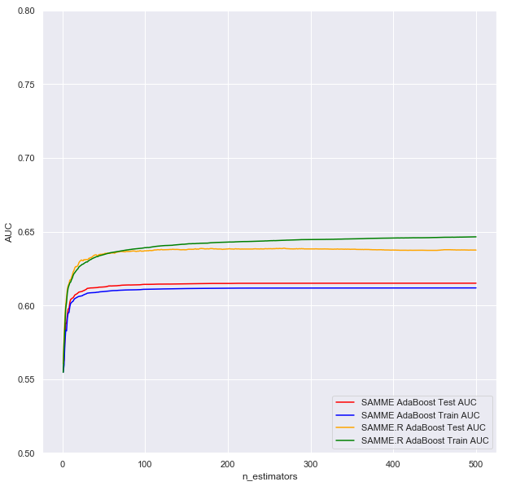

```python
# plotting in-sample and out-of-sample error of both SAMME and SAMME.R AdaBoost algorithms as function of boosting iterations.
# the max number of boosting iterations is given by n_estimators
fig = plt.figure()
ax = fig.add_subplot(111)

ada_err_test = np.zeros((n_estimators,))
for i, y_pred in enumerate(ada.staged_predict_proba(X_test)):
    ada_err_test[i] = roc_auc_score(y_test, y_pred[:,1])

ada_err_train = np.zeros((n_estimators,))
for i, y_pred in enumerate(ada.staged_predict_proba(X_train)):
    ada_err_train[i] =  roc_auc_score(y_train,  y_pred[:,1])

ada_R_err_test = np.zeros((n_estimators,))
for i, y_pred in enumerate(ada_R.staged_predict_proba(X_test)):
    ada_R_err_test[i] =  roc_auc_score(y_test, y_pred[:,1])

ada_R_err_train = np.zeros((n_estimators,))
for i, y_pred in enumerate(ada_R.staged_predict_proba(X_train)):
    ada_R_err_train[i] =  roc_auc_score(y_train, y_pred[:,1])

ax.plot(np.arange(n_estimators) + 1, ada_err_test,
        label='SAMME AdaBoost Test AUC',
        color='red')

ax.plot(np.arange(n_estimators) + 1, ada_err_train,
        label='SAMME AdaBoost Train AUC',
        color='blue')

ax.plot(np.arange(n_estimators) + 1, ada_R_err_test,
        label='SAMME.R AdaBoost Test AUC',
        color='orange')

ax.plot(np.arange(n_estimators) + 1, ada_R_err_train,
        label='SAMME.R AdaBoost Train AUC',
        color='green')

ax.set_ylim((0.5, 0.8))
ax.set_xlabel('n_estimators')
ax.set_ylabel('AUC')

leg = ax.legend(loc='lower right', fancybox=True)
leg.get_frame().set_alpha(0.7)
```

```python
# save plot (insert path to .png and .pdf)
plt.savefig(r'E:\\repository\\ActuarialDataScience\\4 - On Boosting Theory and Applications\\adaboost_st1.png')
plt.savefig(r'E:\\repository\\ActuarialDataScience\\4 - On Boosting Theory and Applications\\adaboost_st1.pdf')
```

```python
# max Gini coefficient for each curve

# ada
print('Max SAMME train Gini:', (2*np.amax(ada_err_train)-1))
print('Max SAMME test Gini:',(2*np.amax(ada_err_test)-1))

# ada_R
print('Max SAMME.R train Gini:',(2*np.amax(ada_R_err_train)-1))
print('Max SAMME.R test Gini:',(2*np.amax(ada_R_err_test)-1))
```

```
Max SAMME train Gini: 0.22365304659776908
Max SAMME test Gini: 0.23004989449021673
Max SAMME.R train Gini: 0.2929158811817818
Max SAMME.R test Gini: 0.2774042645516981
```

```python
# similarly, max AUC for each curve

print('Max SAMME train AUC:', np.amax(ada_err_train))
print('Max SAMME test AUC:',np.amax(ada_err_test))

# ada_R
print('Max SAMME.R train AUC:', np.amax(ada_R_err_train))
print('Max SAMME.R test AUC:', np.amax(ada_R_err_test))
```

```
Max SAMME train AUC: 0.6118265232988845
Max SAMME test AUC: 0.6150249472451084
Max SAMME.R train AUC: 0.6464579405908909
Max SAMME.R test AUC: 0.638702132275849
```

```python
# addendum: retrieve position maximum test AUC SAMME.R
np.argmax(ada_R_err_test)  # if x returned, the number of iterations is x+1
```

```
266
```

#### ST2:hyper parameter tuning: `n_estimators`, `max_depth` and `learning_rate`

```python
# GridSearch AdaBoost optimization (change the hyperparameters according to the run under consideration)
param_grid = {
              'learning_rate': [0.001, 0.001, 0.1, 1],
              'n_estimators': [100, 200, 300, 400]
             }

# tree as base learner
tree = tree = DecisionTreeClassifier(criterion='gini',
                                     random_state=random_state,
                                     max_depth=1)

boost = AdaBoostClassifier(base_estimator=tree,
                           random_state=random_state)

# cross-validation
cv = StratifiedKFold(n_splits=5,
                     shuffle=False,
                     random_state=random_state)

grid_boost = GridSearchCV(estimator=boost,
                          param_grid=param_grid,
                          scoring=score_gini,
                          cv=cv,
                          verbose=10)

grid_boost.fit(X_train, y_train)
```

```
Fitting 5 folds for each of 16 candidates, totalling 80 fits
[CV] learning_rate=0.001, n_estimators=100 ...........................
```

```
[Parallel(n_jobs=1)]: Using backend SequentialBackend with 1 concurrent workers.
```

```
[CV]  learning_rate=0.001, n_estimators=100, score=0.15570008410221006, total= 2.1min
[CV] learning_rate=0.001, n_estimators=100 ...........................
```

```
[Parallel(n_jobs=1)]: Done   1 out of   1 | elapsed:  2.3min remaining:    0.0s
```

```
[CV]  learning_rate=0.001, n_estimators=100, score=0.12082638039876814, total= 2.0min
[CV] learning_rate=0.001, n_estimators=100 ...........................
```

```
[Parallel(n_jobs=1)]: Done   2 out of   2 | elapsed:  4.5min remaining:    0.0s
```

```
[CV]  learning_rate=0.001, n_estimators=100, score=0.10281777772543721, total= 2.0min
[CV] learning_rate=0.001, n_estimators=100 ...........................
```

```
[Parallel(n_jobs=1)]: Done   3 out of   3 | elapsed:  6.6min remaining:    0.0s
```

```
[CV]  learning_rate=0.001, n_estimators=100, score=0.14804255361946067, total= 2.0min
[CV] learning_rate=0.001, n_estimators=100 ...........................
```

```
[Parallel(n_jobs=1)]: Done   4 out of   4 | elapsed:  8.8min remaining:    0.0s
```

```
[CV]  learning_rate=0.001, n_estimators=100, score=0.13676623879042166, total= 2.0min
[CV] learning_rate=0.001, n_estimators=200 ...........................
```

```
[Parallel(n_jobs=1)]: Done   5 out of   5 | elapsed: 11.0min remaining:    0.0s
```

```
[CV]  learning_rate=0.001, n_estimators=200, score=0.15938985971177047, total= 3.9min
[CV] learning_rate=0.001, n_estimators=200 ...........................
```

```
[Parallel(n_jobs=1)]: Done   6 out of   6 | elapsed: 15.3min remaining:    0.0s
```

```
[CV]  learning_rate=0.001, n_estimators=200, score=0.1449053496476778, total= 4.4min
[CV] learning_rate=0.001, n_estimators=200 ...........................
```

```
[Parallel(n_jobs=1)]: Done   7 out of   7 | elapsed: 20.1min remaining:    0.0s
```

```
[CV]  learning_rate=0.001, n_estimators=200, score=0.1363837661650959, total= 3.8min
[CV] learning_rate=0.001, n_estimators=200 ...........................
```

```
[Parallel(n_jobs=1)]: Done   8 out of   8 | elapsed: 24.3min remaining:    0.0s
```

```
[CV]  learning_rate=0.001, n_estimators=200, score=0.15453205625418565, total= 3.7min
[CV] learning_rate=0.001, n_estimators=200 ...........................
```

```
[Parallel(n_jobs=1)]: Done   9 out of   9 | elapsed: 28.4min remaining:    0.0s
```

[output not shown]

[output cut: 86 more lines]

```
[CV]  learning_rate=1, n_estimators=300, score=0.26885983668708086, total= 5.6min
[CV] learning_rate=1, n_estimators=300 ...............................
[CV]  learning_rate=1, n_estimators=300, score=0.26623810455130204, total= 5.6min
[CV] learning_rate=1, n_estimators=300 ...............................
[CV]  learning_rate=1, n_estimators=300, score=0.25697115585349767, total= 5.6min
[CV] learning_rate=1, n_estimators=400 ...............................
[CV]  learning_rate=1, n_estimators=400, score=0.260585513515011, total= 7.6min
[CV] learning_rate=1, n_estimators=400 ...............................
[CV]  learning_rate=1, n_estimators=400, score=0.25941191483900894, total= 7.5min
[CV] learning_rate=1, n_estimators=400 ...............................
[CV]  learning_rate=1, n_estimators=400, score=0.26778616739745664, total= 7.5min
[CV] learning_rate=1, n_estimators=400 ...............................
[CV]  learning_rate=1, n_estimators=400, score=0.26798469069186315, total= 7.5min
[CV] learning_rate=1, n_estimators=400 ...............................
[CV]  learning_rate=1, n_estimators=400, score=0.25703900960427684, total= 7.6min
```

```
[Parallel(n_jobs=1)]: Done  80 out of  80 | elapsed: 417.4min finished
```

```
GridSearchCV(cv=StratifiedKFold(n_splits=5, random_state=123, shuffle=False),
       error_score='raise-deprecating',
       estimator=AdaBoostClassifier(algorithm='SAMME.R',
          base_estimator=DecisionTreeClassifier(class_weight=None, criterion='gini', max_depth=1,
            max_features=None, max_leaf_nodes=None,
            min_impurity_decrease=0.0, min_impurity_split=None,
            min_samples_leaf=1, min_samples_split=2,
            min_weight_fraction_leaf=0.0, presort=False, random_state=123,
            splitter='best'),
          learning_rate=1.0, n_estimators=50, random_state=123),
       fit_params=None, iid='warn', n_jobs=None,
       param_grid={'learning_rate': [0.001, 0.001, 0.1, 1], 'n_estimators': [100, 200, 300, 400]},
       pre_dispatch='2*n_jobs', refit=True, return_train_score='warn',
       scoring=make_scorer(gini_normalized_score, needs_threshold=True),
       verbose=10)
```

```python
# best model/classifier
clf_b = grid_boost.best_estimator_
clf_b
```

```
AdaBoostClassifier(algorithm='SAMME.R',
          base_estimator=DecisionTreeClassifier(class_weight=None, criterion='gini', max_depth=1,
            max_features=None, max_leaf_nodes=None,
            min_impurity_decrease=0.0, min_impurity_split=None,
            min_samples_leaf=1, min_samples_split=2,
            min_weight_fraction_leaf=0.0, presort=False, random_state=123,
            splitter='best'),
          learning_rate=0.1, n_estimators=400, random_state=123)
```

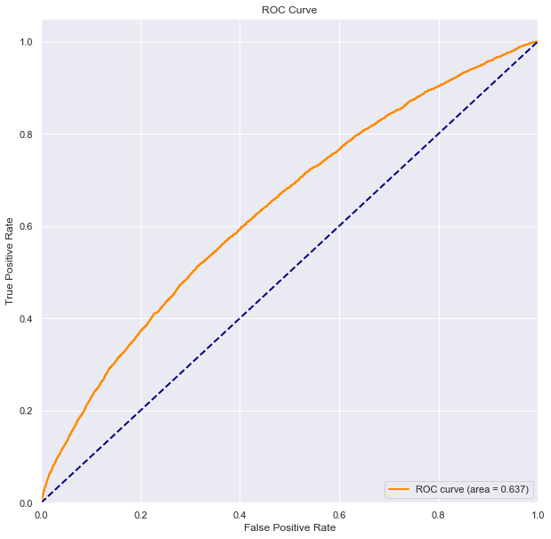

```
AUC: 0.637
```

```python
# computing out-of-sample AUC for best classifier
clf_b.fit(X_train, y_train)

# test data: computing AUC
y_scores = clf_b.decision_function(X_test)
fpr, tpr, _ = roc_curve(y_test, y_scores)
roc_auc = auc(fpr, tpr)

# plotting ROC and showing AUC (on test data)
plt.figure()
lw = 2
plt.plot(fpr, tpr, color='darkorange', lw=lw, label='ROC curve (area = %0.3f)' % roc_auc)
plt.plot([0, 1], [0, 1], color='navy', lw=lw, linestyle='--')
plt.xlim([0.0, 1.0])
plt.ylim([0.0, 1.05])
plt.xlabel('False Positive Rate')
plt.ylabel('True Positive Rate')
plt.title('ROC Curve')
plt.legend(loc="lower right")
plt.show()

# AUC on test dataset
print('AUC:', roc_auc_score(y_test, y_scores).round(3))
```

## Boosting: XGBoost

We continue the boosting analysis with **XGBoost**. We do implement 2 separate strategies: **ST0** and **ST1**.

#### ST0: default XGBoost with `XGBClassifier()`

Below the hyper-parameters of the default `XGBClassifier()` implementation are presented and fitting on `X_train` is performed.

```python
# fit model default hyper-parameters
xgb_default = XGBClassifier(random_state=random_state)
xgb_default.set_params()
```

```
XGBClassifier(base_score=0.5, booster='gbtree', colsample_bylevel=1,
       colsample_bynode=1, colsample_bytree=1, gamma=0, learning_rate=0.1,
       max_delta_step=0, max_depth=3, min_child_weight=1, missing=None,
       n_estimators=100, n_jobs=1, nthread=None,
       objective='binary:logistic', random_state=123, reg_alpha=0,
       reg_lambda=1, scale_pos_weight=1, seed=None, silent=None,
       subsample=1, verbosity=1)
```

```python
# fitting the default XGBoostClassifier()
xgb_default.fit(X_train, y_train)
```

```
XGBClassifier(base_score=0.5, booster='gbtree', colsample_bylevel=1,
       colsample_bynode=1, colsample_bytree=1, gamma=0, learning_rate=0.1,
       max_delta_step=0, max_depth=3, min_child_weight=1, missing=None,
       n_estimators=100, n_jobs=1, nthread=None,
       objective='binary:logistic', random_state=123, reg_alpha=0,
       reg_lambda=1, scale_pos_weight=1, seed=None, silent=None,
       subsample=1, verbosity=1)
```

```python
# default XGBoost classifier performance
y_pred_proba_xgb_default = xgb_default.predict_proba(X_test)
fpr, tpr, _ = roc_curve(y_test, y_pred_proba_xgb_default[:, 1])
roc_auc = auc(fpr, tpr)

# AUC on test dataset
print('AUC:', roc_auc_score(y_test, y_pred_proba_xgb_default[:, 1]).round(3))
```

```
AUC: 0.638
```

#### ST1: hyper parameter tuning:`max_depth`, `learning_rate`, `n_estimators` with fixed subsampling

```python
# GridSearch XGBoost optimization (change the hyperparameters according to the run under consideration)
param_grid = {'max_depth': [1],
              'learning_rate': [0.001, 0.01, 0.1, 1],
              'n_estimators': [100, 300, 500],
              'subsample': [0.5],
              'colsample_bytree': [0.75]
             }

# cross-validation
cv = StratifiedKFold(n_splits=5,
                     shuffle=False,
                     random_state=random_state)

xgb = GridSearchCV(estimator=XGBClassifier(random_state=random_state),
                   param_grid=param_grid,
                   scoring=score_gini,
                   cv=cv,
                   verbose=10)

xgb.fit(X_train, y_train)
```

```
Fitting 5 folds for each of 12 candidates, totalling 60 fits
```

```
[Parallel(n_jobs=1)]: Using backend SequentialBackend with 1 concurrent workers.
```

```
[CV] colsample_bytree=0.75, learning_rate=0.001, max_depth=1, n_estimators=100, subsample=0.5
[CV]  colsample_bytree=0.75, learning_rate=0.001, max_depth=1, n_estimators=100, subsample=0.5, score=0.1900779525946243, total= 1.6min
[CV] colsample_bytree=0.75, learning_rate=0.001, max_depth=1, n_estimators=100, subsample=0.5
```

```
[Parallel(n_jobs=1)]: Done   1 out of   1 | elapsed:  1.6min remaining:    0.0s
```

```
[CV]  colsample_bytree=0.75, learning_rate=0.001, max_depth=1, n_estimators=100, subsample=0.5, score=0.1691553041871399, total= 1.3min
[CV] colsample_bytree=0.75, learning_rate=0.001, max_depth=1, n_estimators=100, subsample=0.5
```

```
[Parallel(n_jobs=1)]: Done   2 out of   2 | elapsed:  3.0min remaining:    0.0s
```

```
[CV]  colsample_bytree=0.75, learning_rate=0.001, max_depth=1, n_estimators=100, subsample=0.5, score=0.18652597223989426, total= 1.3min
[CV] colsample_bytree=0.75, learning_rate=0.001, max_depth=1, n_estimators=100, subsample=0.5
```

```
[Parallel(n_jobs=1)]: Done   3 out of   3 | elapsed:  4.4min remaining:    0.0s
```

```
[CV]  colsample_bytree=0.75, learning_rate=0.001, max_depth=1, n_estimators=100, subsample=0.5, score=0.20015176887755803, total= 1.4min
[CV] colsample_bytree=0.75, learning_rate=0.001, max_depth=1, n_estimators=100, subsample=0.5
```

```
[Parallel(n_jobs=1)]: Done   4 out of   4 | elapsed:  5.9min remaining:    0.0s
```

```
[CV]  colsample_bytree=0.75, learning_rate=0.001, max_depth=1, n_estimators=100, subsample=0.5, score=0.188624185300641, total= 1.4min
[CV] colsample_bytree=0.75, learning_rate=0.001, max_depth=1, n_estimators=300, subsample=0.5
```

```
[Parallel(n_jobs=1)]: Done   5 out of   5 | elapsed:  7.4min remaining:    0.0s
```

```
[CV]  colsample_bytree=0.75, learning_rate=0.001, max_depth=1, n_estimators=300, subsample=0.5, score=0.20035704068915527, total= 4.0min
[CV] colsample_bytree=0.75, learning_rate=0.001, max_depth=1, n_estimators=300, subsample=0.5
```

```
[Parallel(n_jobs=1)]: Done   6 out of   6 | elapsed: 11.5min remaining:    0.0s
```

```
[CV]  colsample_bytree=0.75, learning_rate=0.001, max_depth=1, n_estimators=300, subsample=0.5, score=0.17896007067408873, total= 4.1min
[CV] colsample_bytree=0.75, learning_rate=0.001, max_depth=1, n_estimators=300, subsample=0.5
```

```
[Parallel(n_jobs=1)]: Done   7 out of   7 | elapsed: 15.7min remaining:    0.0s
```

```
[CV]  colsample_bytree=0.75, learning_rate=0.001, max_depth=1, n_estimators=300, subsample=0.5, score=0.19826129407735085, total= 4.0min
[CV] colsample_bytree=0.75, learning_rate=0.001, max_depth=1, n_estimators=300, subsample=0.5
```

```
[Parallel(n_jobs=1)]: Done   8 out of   8 | elapsed: 19.7min remaining:    0.0s
```

```
[CV]  colsample_bytree=0.75, learning_rate=0.001, max_depth=1, n_estimators=300, subsample=0.5, score=0.19952893541782526, total= 3.9min
[CV] colsample_bytree=0.75, learning_rate=0.001, max_depth=1, n_estimators=300, subsample=0.5
```

```
[Parallel(n_jobs=1)]: Done   9 out of   9 | elapsed: 23.7min remaining:    0.0s
```

[output not shown]

[output cut: 46 more lines]

```
[CV]  colsample_bytree=0.75, learning_rate=1, max_depth=1, n_estimators=300, subsample=0.5, score=0.26397436928661433, total= 4.2min
[CV] colsample_bytree=0.75, learning_rate=1, max_depth=1, n_estimators=300, subsample=0.5
[CV]  colsample_bytree=0.75, learning_rate=1, max_depth=1, n_estimators=300, subsample=0.5, score=0.25959727427171936, total= 4.1min
[CV] colsample_bytree=0.75, learning_rate=1, max_depth=1, n_estimators=300, subsample=0.5
[CV]  colsample_bytree=0.75, learning_rate=1, max_depth=1, n_estimators=300, subsample=0.5, score=0.2470219716374483, total= 4.1min
[CV] colsample_bytree=0.75, learning_rate=1, max_depth=1, n_estimators=500, subsample=0.5
[CV]  colsample_bytree=0.75, learning_rate=1, max_depth=1, n_estimators=500, subsample=0.5, score=0.25208275631185556, total= 6.8min
[CV] colsample_bytree=0.75, learning_rate=1, max_depth=1, n_estimators=500, subsample=0.5
[CV]  colsample_bytree=0.75, learning_rate=1, max_depth=1, n_estimators=500, subsample=0.5, score=0.2516679038589328, total= 6.8min
[CV] colsample_bytree=0.75, learning_rate=1, max_depth=1, n_estimators=500, subsample=0.5
[CV]  colsample_bytree=0.75, learning_rate=1, max_depth=1, n_estimators=500, subsample=0.5, score=0.2600206323346296, total= 7.3min
[CV] colsample_bytree=0.75, learning_rate=1, max_depth=1, n_estimators=500, subsample=0.5
[CV]  colsample_bytree=0.75, learning_rate=1, max_depth=1, n_estimators=500, subsample=0.5, score=0.25642929934061437, total= 7.0min
[CV] colsample_bytree=0.75, learning_rate=1, max_depth=1, n_estimators=500, subsample=0.5
[CV]  colsample_bytree=0.75, learning_rate=1, max_depth=1, n_estimators=500, subsample=0.5, score=0.25016698097543044, total= 7.0min
```

```
[Parallel(n_jobs=1)]: Done  60 out of  60 | elapsed: 254.2min finished
```

```
GridSearchCV(cv=StratifiedKFold(n_splits=5, random_state=123, shuffle=False),
       error_score='raise-deprecating',
       estimator=XGBClassifier(base_score=0.5, booster='gbtree', colsample_bylevel=1,
       colsample_bynode=1, colsample_bytree=1, gamma=0, learning_rate=0.1,
       max_delta_step=0, max_depth=3, min_child_weight=1, missing=None,
       n_estimators=100, n_jobs=1, nthread=None,
       objective='binary:logistic', random_state=123, reg_alpha=0,
       reg_lambda=1, scale_pos_weight=1, seed=None, silent=None,
       subsample=1, verbosity=1),
       fit_params=None, iid='warn', n_jobs=None,
       param_grid={'max_depth': [1], 'learning_rate': [0.001, 0.01, 0.1, 1], 'n_estimators': [100, 300, 500], 'subsample': [0.5], 'colsample_bytree': [0.75]},
       pre_dispatch='2*n_jobs', refit=True, return_train_score='warn',
       scoring=make_scorer(gini_normalized_score, needs_threshold=True),
       verbose=10)
```

```python
# best score on CV-data
print('Best Gini on CV-data:', xgb.best_score_)

# parameters for best model
print('Best set of hyperparameters:', xgb.best_params_)
```

```
Best Gini on CV-data: 0.26673980845586565
Best set of hyperparameters: {'colsample_bytree': 0.75, 'learning_rate': 0.1, 'max_depth': 1, 'n_estimators': 500, 'subsample': 0.5}
```

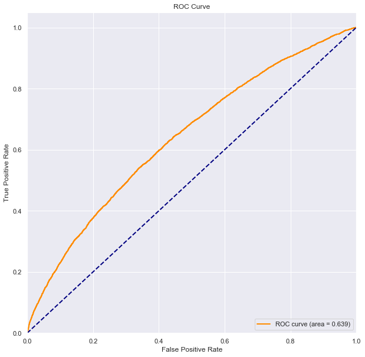

```
AUC: 0.639
```

```python
# best xgb model
xgb_best = xgb.best_estimator_
xgb_best.fit(X_train, y_train)

# best xgb predictions on test data and AUC
y_pred_proba_xgb = xgb_best.predict_proba(X_test)
fpr, tpr, _ = roc_curve(y_test, y_pred_proba_xgb[:, 1])
roc_auc = auc(fpr, tpr)

# plotting ROC and showing AUC (on test data)
plt.figure()
lw = 2
plt.plot(fpr, tpr, color='darkorange', lw=lw, label='ROC curve (area = %0.3f)' % roc_auc)
plt.plot([0, 1], [0, 1], color='navy', lw=lw, linestyle='--')
plt.xlim([0.0, 1.0])
plt.ylim([0.0, 1.05])
plt.xlabel('False Positive Rate')
plt.ylabel('True Positive Rate')
plt.title('ROC Curve')
plt.legend(loc="lower right")
plt.show()

# AUC on test dataset
print('AUC:', roc_auc_score(y_test, y_pred_proba_xgb[:, 1]).round(3))
```

```python
# fitting best model (again, if not saved beforehand)
xgb_best_ov = XGBClassifier(max_depth=3,
                            learning_rate=0.1,
                            n_estimators=300,
                            subsample=0.5,
                            colsample_bytree=0.75,
                            random_state=random_state)
xgb_best_ov.fit(X_train, y_train)
```

```
XGBClassifier(base_score=0.5, booster='gbtree', colsample_bylevel=1,
       colsample_bynode=1, colsample_bytree=0.75, gamma=0,
       learning_rate=0.1, max_delta_step=0, max_depth=3,
       min_child_weight=1, missing=None, n_estimators=300, n_jobs=1,
       nthread=None, objective='binary:logistic', random_state=123,
       reg_alpha=0, reg_lambda=1, scale_pos_weight=1, seed=None,
       silent=None, subsample=0.5, verbosity=1)
```

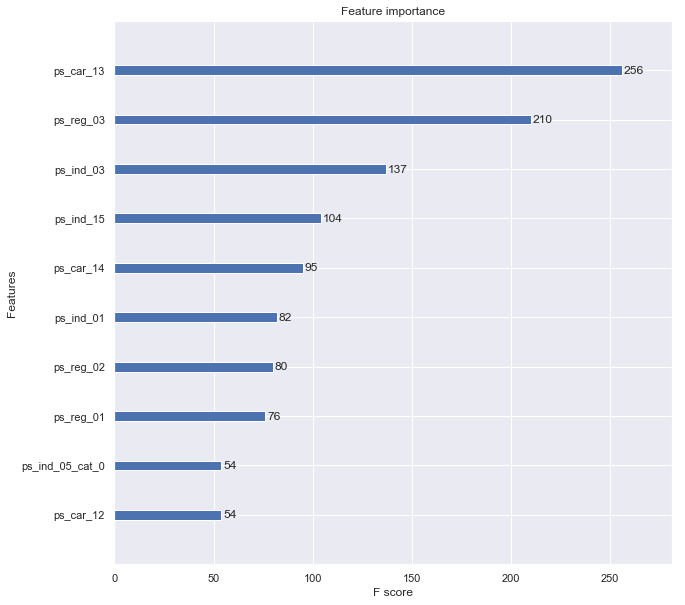

```python
# plotting feature importance graph: top 10 features
plot_importance(xgb_best_ov, max_num_features=10)
```